# Exploratory Analysis

## How Basketball has changed in the NBA Over the Years. Who Does it Best?

### Authors

- Jack Ly (jaly1203@uw.edu)

### Date

Spring 2024

### Abstract

The way that basketball has been played in the NBA has changed greatly over the course of history, whether that be from various rule changes to overall strategy. What I want to figure out with this project is how exactly the game has changed over the years and how much it has affected the game on a more personal level. To do this, I plan to analyze various stat differentials between different seasons, and which team have adapted best over the years.

### Keywords

NBA, Basketball, Statistics

### Introduction

Basketball, especially in the NBA, has gone through many significant transformations since the beginning. These changes include many things like strategy, rules changes, players roles, advancements, and more. The main thing that I want to identify is what changes occurred and how they affected the current NBA. This question is the main motivation for the entire project and it aims to highlight the old and current trends in basketball in the NBA. As with any game, knowing how the game has changed is incredibly important and necessary for analyzing who the best teams/players really are. This goes to the next question. Which teams have performed best from each era of the NBA? The best teams are capable of adapting to the current game and keeping up with the competition in order to stay competitive and on top of the rest of the league. This can be argued with player dominance and how strategy just did not matter in the face of certain players, however it should be noted that building a team around a dominant player is also a strategy as well as double/triple teaming certain players. The last question that I wish to ask is how player flexibility has changed overall, as certain players like Jokic have redefined in recent time how to play center.

### Related Work

Describe your topic and related work in this space. You must include 3 citations to related work (URLs to similar work, high quality articles from the popular press, research papers, etc. ) Please use a standard citation style of your choice. (at least 200 words)

- My topic is on how the NBA has changed over the years, and which teams have best kept up with the trends of these changes. This includes observing changes like changes in overall play style, changes in rules, and more, and how they have affected the league and the way people play. I think the main motivation for working on this project was definitely the more aggressive 3 point shooting scheme that has happened in the more recent years, especially with Steph Curry and the Golden State Warriors. Steve Kerr coaching and utilizing Curry’s 3 point shooting ability “revolutionized” the way that the game was played at that point, creating unprecedented numbers and scoring. Other than that another big topic that I wanted to talk about was how the game has changed in terms of physicality. In today’s NBA, you get away with a lot less in terms of what is called a foul, and as such you have many players who fish for fouls by blatantly flopping in order to sell that they were fouled. Despite that I am of the opinion that there are more floppers than back then, In the article I read, I think KD puts it perfectly, many old NBA fans will claim that the game back then was a lot more physical, but in reality, the game has just changed to be less tolerant.

#### References

- Morse, Ben. “Steph Curry: How Golden State Warriors Star “Revolutionized” the NBA.” CNN, 15 Dec. 2021, www.cnn.com/2021/12/14/sport/steph-curry-ray-allen-three-point-record-spt-intl/index.html.
- “Kevin Durant on Why NBA “Seemed” Tougher in 1980s and ’90s: “They Got Away with a Lot of Flagrant Fouls.”” CBSSports.com, 6 Apr. 2023, www.cbssports.com/nba/news/kevin-durant-on-why-nba-seemed-tougher-in-80s-and-90s-they-got-away-with-a-lot-of-flagrant-fouls/.
- Schuhmann, John. “NBA’s 3-Point Revolution: How 1 Shot Is Changing the Game.” Www.nba.com, 14 Oct. 2021, www.nba.com/news/3-point-era-nba-75.

### The Dataset

Where did you find the data? Please include a link to the data source

- https://www.kaggle.com/datasets/rodneycarroll78/nba-stats-1980-2024 (MAIN LINK TO ALL CSVs)
- https://www.kaggle.com/datasets/rodneycarroll78/nba-stats-1980-2024?select=Team+Summaries.csv (TEAM SUMMARY)
- https://www.kaggle.com/datasets/rodneycarroll78/nba-stats-1980-2024?select=Team+Totals.csv (TEAM TOTAL)

Who collected the data?

- Rodney Carroll

How was the data collected or generated?

- Statistics were pulled and aggregated into different CSVs from Basketball Reference.

Why was the data collected?

- To record various seasonal stats and accolades of both players and teams.

How many observations (rows) are in your data?

- 1254 (TEAM SUMMARY)
- 1845 (TEAM TOTAL)

How many features (columns) are in the data?

- 29 (TEAM SUMMARY)
- 28 (TEAM TOTAL)

What, if any, ethical questions or questions of power do you need to consider when working with this data?

- Not really any questions of power per se since this data is largely just for sports analysis, however it is important to note that data is objective, but what one individual gets from the data changes from person to person, so it really is on me to put forth the best product I can to avoid pushing false narratives.

What are possible limitations or problems with this data? (at least 200 words)

- Although Basketball Reference is a relatively straightforward and trusted source for basketball information and statistics, it still is not technically an official source of all NBA statistics. You could get the data straight from the NBA, but there are a lot of hidden stats that Basketball Reference includes in their data set. Not to mention that the data set that I am using is not actually straight from Basketball reference, but rather it is aggregated by a different individual to be more compact and usable in the CSV format. This could be a problem, as the data could be partially incorrect in some areas because of incorrect data insertion or formatting. But, for the most part, I doubt that this will be a problem, as with the way that the CSV is formatted, there are not many ways that information could be stored incorrectly. If there are any problems, it should be easily dealt with. One of the potential problems that I previously thought about was how the data set sometimes included values under the league when it was the ABA, but once again, that should not be much of a problem, as if I really want to filter out those values, then I can.

### Implications

Assuming you answer your research questions, briefly describe the expected or possible implications for technologists, designers, and policymakers. (at least 150 words)

- Some of the expected results that I think I am going to see from this relates to the ways that the game has changed overall in the way it is played over the years. More specifically how prevalent the 3 point shot has become in today’s game in comparison to 80s - early 90s. I know that the 3 point line was changed to be shorter, which did increase 3 point shooting to an extent, but the NBA changed it back to its original distance, and interestingly enough, only years later did 3 point shooting become the norm. A lot of older fans will complain that the game has too many 3 point shooters now in comparison to the more aggressive mid range game back then, but just like anything else, I think that that is part of the adaptations and changing the way the game is played. In recent years, there has been potential news of a 4 point line coming, which is actually a sign of change to adapt and reward those who have stuck with 3 point shooting, however it might be years until it is actually seen. Personally, I don’t like it as it might trivialize the mid range game more.

### Limitations & Challenges

What challenges or limitations might you need to address with your project idea more broadly? Briefly discuss. (at least 150 words)

- One of the main challenges that I think I will deal with is finding a way to sort my data in a reasonable non biased manner. The primary issue is that scoring in the 90s era of basketball was a lot more slow and methodical, meaning that there was significantly less scoring, and overall less 3 point attempts. So, if I were to compare the 3 point attempts from back then to the current day scoring where it is much higher, then I would have to set a proportion, like 3 point attempts divided by 2 point attempts, in order to get a more accurate statistic/proportion. Other than that, I think the only problem would be figuring out what other statistics that I could show that would represent change in how the game changed over the years. I am mainly thinking of using 3 point shooting as a basis, with free throws/personal fouls to show the game becoming less tolerant of physicality.

### Summary Information

- While sorting some values from the data, I found that some of my guesses were correct while other weren’t. One of the most dominant seasons that occurred to date was the 2016 championship run for the the Warriors which had them at the highest amount of wins in one season at 73. Unsurprisingly, the Lakers have overall the most game wins in total throughout all seasons since 1980 with 2186 despite their more poor performance in recent years. As well as this, the Celtics lead the league in points scored since 1980 with 643702, and the Nuggets lead the most points scored in one season in 1982 with 10371 point scored. And interestingly enough, the most personal fouls gotten in a season occurred in 1978 with 2470 from the Atlanta Hawks.

### Aggregate Table

| Season | Team | Wins | Losses | 3 Point Attempts | Personal Fouls |
| --- | --- | --- | --- | --- | --- |
| 2023 | Atlanta Hawks | 41 | 41 | 2505 | 1541 |
| 1999 | Atlanta Hawks | 31 | 19 | 644 | 987 |
| 2023 | Boston Celtics | 57 | 25 | 3492 | 1542 |
| 1999 | Boston Celtics | 19 | 31 | 758 | 1193 |
| 2023 | Brooklyn Nets | 45 | 37 | 2771 | 1730 |
| 2023 | Charlotte Hornets | 27 | 55 | 2669 | 1661 |
| 1999 | Charlotte Hornets | 26 | 24 | 735 | 1101 |
| 2023 | Chicago Bulls | 40 | 42 | 2367 | 1551 |
| 1999 | Chicago Bulls | 13 | 37 | 612 | 1112 |
| 2023 | Cleveland Cavaliers | 51 | 31 | 2589 | 1560 |
| 1999 | Cleveland Cavaliers | 22 | 28 | 534 | 1208 |
| 2023 | Dallas Mavericks | 38 | 44 | 3362 | 1697 |
| 1999 | Dallas Mavericks | 19 | 31 | 595 | 1065 |
| 2023 | Denver Nuggets | 53 | 29 | 2559 | 1525 |
| 1999 | Denver Nuggets | 14 | 36 | 922 | 1145 |
| 2023 | Detroit Pistons | 17 | 65 | 2659 | 1813 |
| 1999 | Detroit Pistons | 29 | 21 | 679 | 1139 |
| 2023 | Golden State Warriors | 44 | 38 | 3540 | 1757 |
| 1999 | Golden State Warriors | 21 | 29 | 565 | 1270 |
| 2023 | Houston Rockets | 22 | 60 | 2619 | 1679 |
| 1999 | Houston Rockets | 31 | 19 | 914 | 960 |
| 2023 | Indiana Pacers | 35 | 47 | 3030 | 1741 |
| 1999 | Indiana Pacers | 33 | 17 | 799 | 1082 |
| 2023 | Los Angeles Clippers | 44 | 38 | 2735 | 1598 |
| 1999 | Los Angeles Clippers | 9 | 41 | 668 | 1223 |
| 2023 | Los Angeles Lakers | 43 | 39 | 2558 | 1466 |
| 1999 | Los Angeles Lakers | 31 | 19 | 685 | 1231 |
| 2023 | Memphis Grizzlies | 51 | 31 | 2807 | 1643 |
| 2023 | Miami Heat | 44 | 38 | 2852 | 1516 |
| 1999 | Miami Heat | 33 | 17 | 804 | 1035 |
| 2023 | Milwaukee Bucks | 58 | 24 | 3306 | 1481 |
| 1999 | Milwaukee Bucks | 28 | 22 | 619 | 1142 |
| 2023 | Minnesota Timberwolves | 42 | 40 | 2731 | 1768 |
| 1999 | Minnesota Timberwolves | 25 | 25 | 410 | 1185 |
| 1999 | New Jersey Nets | 16 | 34 | 679 | 1134 |
| 2023 | New Orleans Pelicans | 42 | 40 | 2468 | 1678 |
| 2023 | New York Knicks | 47 | 35 | 2930 | 1666 |
| 1999 | New York Knicks | 27 | 23 | 589 | 1140 |
| 2023 | Oklahoma City Thunder | 40 | 42 | 2797 | 1722 |
| 2023 | Orlando Magic | 34 | 48 | 2551 | 1652 |
| 1999 | Orlando Magic | 33 | 17 | 675 | 935 |
| 2023 | Philadelphia 76ers | 54 | 28 | 2675 | 1675 |
| 1999 | Philadelphia 76ers | 28 | 22 | 371 | 1152 |
| 2023 | Phoenix Suns | 45 | 37 | 2674 | 1739 |
| 1999 | Phoenix Suns | 27 | 23 | 702 | 1022 |
| 2023 | Portland Trail Blazers | 33 | 49 | 2893 | 1643 |
| 1999 | Portland Trail Blazers | 35 | 15 | 675 | 1126 |
| 2023 | Sacramento Kings | 48 | 34 | 3060 | 1616 |
| 1999 | Sacramento Kings | 27 | 23 | 943 | 1016 |
| 2023 | San Antonio Spurs | 22 | 60 | 2640 | 1630 |
| 1999 | San Antonio Spurs | 37 | 13 | 521 | 1010 |
| 1999 | Seattle SuperSonics | 25 | 25 | 899 | 1047 |
| 2023 | Toronto Raptors | 41 | 41 | 2626 | 1641 |
| 1999 | Toronto Raptors | 23 | 27 | 662 | 1139 |
| 2023 | Utah Jazz | 37 | 45 | 3099 | 1679 |
| 1999 | Utah Jazz | 37 | 13 | 388 | 1133 |
| 1999 | Vancouver Grizzlies | 8 | 42 | 453 | 1123 |
| 2023 | Washington Wizards | 35 | 47 | 2601 | 1539 |
| 1999 | Washington Wizards | 18 | 32 | 580 | 1151 |

I think that the table shows the more important changes in play that basketball in the NBA has undergone throughout a 20 year period. More notably, the sheer amount of 3 point attempts being made from the modern day to 20 years ago. It also shows the environment for each team and how well they have done under the 3 point shooting game of today versus back then.

### 3 Point Attempts throughout the Years

The reason I chose this chart is so to display how the change in strategy during 2010s created an insane surge in 3 point shooting. You can see how in about 1995, when the 3 point line was shortened, there was a short surge of increased 3 point attempts, however it sooned dipped again once teams settled back into the more slow and methodical play style. Then, come 2010 and beyond, there was a huge surge in 3 point shooting from the likes of Steph Curry, James Harden, and more. Now in 2024, the 3 point shot is practiced unlike it was back then, owing to the hugely increase 3 point attempts in the NBA.

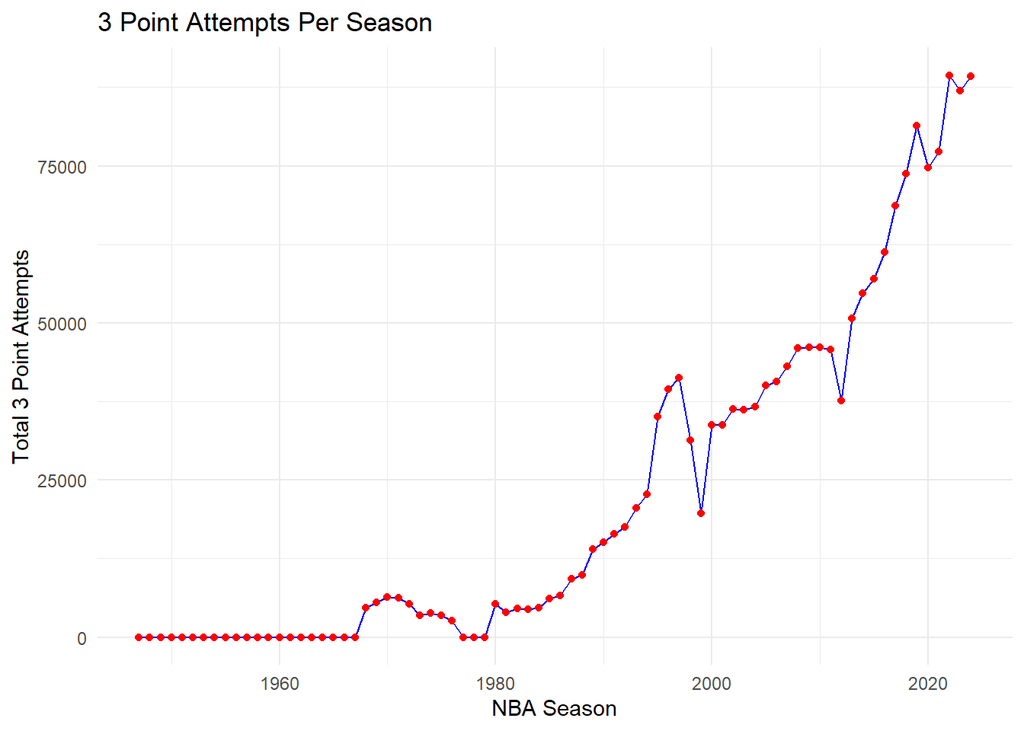

### Personal Fouls Throughout the Years

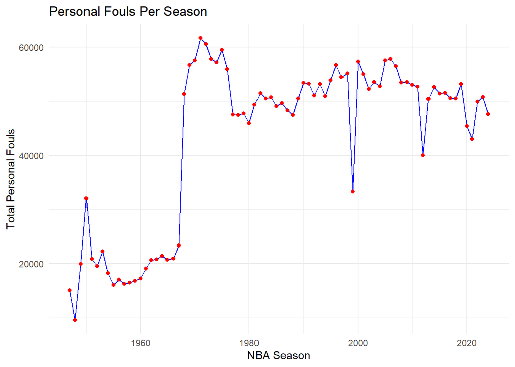

Personal Fouls is another topic that I wanted to talk about during this project, as another one of the main complaints that older fans have about today’s NBA, is that the game isn’t nearly as physical as it was back then. This chart shows the total fouls calculated per season of the NBA, and disregarding the boom in the late 1960s, since that was when many teams started joining the league, we can notice that from 1980 to 1990, there was a small upwards trend for fouling, and from early 2000 onward, there has been a small downwards trend in terms of fouling. Despite this, the graph shows almost negligible change in terms of large trend shifts in fouling. In my opinion, there are a lot of factors to this, but for the most part, the 3 point game of today in addition to more harsh foul calling probably has led to the slightly decreased personal fouls of today, while in the 80s and 90s.

### Who Are the Most Dominant Teams of Each Era?

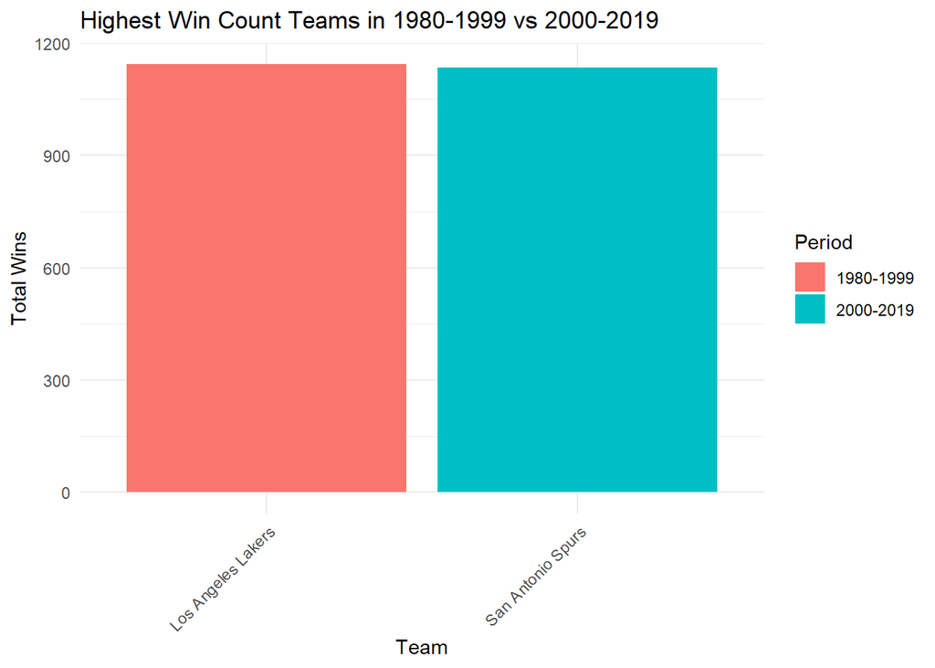

The 1980s to 1999 as well as the 2000-2019 onward have been where some of the most prominent changes have happened in terms of play style and rules. The mid range game and physicality of the 1980s and 1990s and the 3 point game and higher technical skill of the 2000s onward are some of the most notable traits of each era. This chart aims to show what team were most dominant in each era in terms of wins. In this you can see the Lakers dominated the older era while the Spurs had the most wins in the next 20 years.